GeoStat Lab · M11 · Statistica spaziale

M11_N07 · Locus

# Una carta di punti, non una superficie

5 blocchi R eseguiti2 grafici0 errori · 0 avvisiOffline · MathML

Codice, output e figure dello stesso svolgimento. Ogni notebook riparte dai dati locali ed è autonomo rispetto agli altri.

# La domanda

Che cosa mostra una carta di valori puntuali e che cosa rimane non osservato?

## Obiettivi

- Associare colori a concentrazioni con una scala esplicita.
- Conservare geometria e supporto puntuale.
- Distinguere distribuzione marginale e disposizione spaziale.

**Prima di iniziare.** Sono richiesti vettori, tabelle, coordinate e funzioni R di base. I blocchi vanno eseguiti in ordine; il notebook è autonomo rispetto agli altri. I calcoli usano R base e i pacchetti standard.

**Dati e unità.** 64 siti sintetici su una griglia 8 × 8, con passo 250 m e coordinate locali x_m e y_m fra 0 e 1750 m. Questo piano locale non ha un codice EPSG. La concentrazione è sintetica, in unità arbitrarie (u.a.); la quota è in metri sintetici. Ogni riga descrive un sito e il suo valore puntuale, non la media di una cella.

## Preparazione

Aprire il progetto autonomo di Locus o quello generale dei notebook. I CSV locali restano invariati. Gli output vanno in `Risultati/M11_N07/`. Nessun download o installazione viene eseguito nei blocchi.

Codice R · preparazione

```r
# Trova il modulo dal progetto autonomo o dal progetto generale dei notebook.
.gs_cerca <- normalizePath(getwd(),winslash="/",mustWork=TRUE)
repeat {
  .gs_candidati <- c(.gs_cerca,file.path(.gs_cerca,"M11_Locus"),
    file.path(.gs_cerca,"03_Notebook_svolti","M11_Locus"),
    file.path(.gs_cerca,"M11","03_Notebook_svolti","M11_Locus"))
  .gs_ok <- file.exists(file.path(.gs_candidati,"M11_N01.Rmd")) &
    file.exists(file.path(.gs_candidati,"R","funzioni_notebook.R"))
  if(any(.gs_ok)) { .gs_modulo <- .gs_candidati[which(.gs_ok)[1L]];break }
  .gs_padre <- dirname(.gs_cerca)
  if(.gs_padre==.gs_cerca) stop("Aprire il progetto M11_Locus o quello generale dei notebook.")
  .gs_cerca <- .gs_padre
}
source(file.path(.gs_modulo,"R","funzioni_notebook.R"),local=TRUE)
.gs_funzioni <- .gs_prepara_notebook(.gs_modulo,"M11_N07")
carica_dati <- .gs_funzioni$carica_dati
percorso_risultati <- .gs_funzioni$percorso_risultati
options(width=88,digits=6)
if(requireNamespace("knitr",quietly=TRUE)) {
  knitr::opts_chunk$set(echo=TRUE,error=FALSE,warning=TRUE,message=TRUE,
    fig.width=8,fig.height=5,dpi=150,fig.align="center")
}
set.seed(11007)
```

## 1. Valori e scala cromatica

Prima della mappa riassumiamo l’intervallo e il numero di misure, mantenendo le unità arbitrarie del dato sintetico.

Codice R · passo_01

```r
d <- carica_dati("spazio_v3.csv")
audit_spazio(d)
 data.frame(n=nrow(d),minimo=min(d$concentrazione),massimo=max(d$concentrazione),
   media=mean(d$concentrazione),deviazione_standard=sd(d$concentrazione),unita="u.a.")
 quantile(d$concentrazione,c(0,.25,.5,.75,1))
```

Output eseguito

```
   n  minimo massimo   media deviazione_standard unita
1 64 10.8835 23.7749 17.1903             3.00811  u.a.
     0%     25%     50%     75%    100%
10.8835 15.2532 17.0350 18.9426 23.7749
```

**Lettura del risultato.** La sintesi marginale non usa le coordinate. Due configurazioni geografiche possono avere lo stesso istogramma e un’associazione spaziale diversa.

## 2. I punti conservano il supporto osservato

Il grafico disegna soltanto i 64 siti e usa una legenda continua per i 20 intervalli cromatici.

Codice R · passo_02

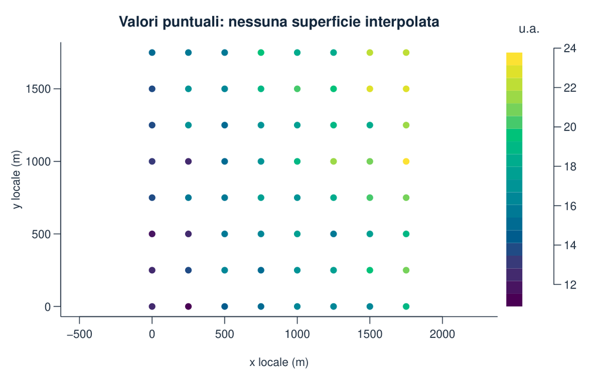

Figura 1 · Output del blocco `passo_02`. PDF vettoriale.

```r
mappa_valori(d,"Valori puntuali: nessuna superficie interpolata")
```

**Lettura del risultato.** Il colore si riferisce a un sito. Il bianco fra i punti non indica concentrazione nulla e non costituisce una previsione: rappresenta assenza di osservazione nella carta.

## 3. La tabella rende la scala ricostruibile

Registriamo classe e colore di ogni misura senza sostituire il valore numerico originale.

Codice R · passo_03

```r
limiti <- seq(min(d$concentrazione),max(d$concentrazione),length.out=21)
classe <- cut(d$concentrazione,limiti,include.lowest=TRUE,labels=FALSE)
tab <- data.frame(id=d$id,x_m=d$x_m,y_m=d$y_m,concentrazione=d$concentrazione,
  classe=classe,colore=hcl.colors(20,"Viridis")[classe])
head(tab,6)
write.csv(tab,percorso_risultati("mappa_punti.csv"),row.names=FALSE)
write.csv(data.frame(limite=limiti),percorso_risultati("scala_cromatica.csv"),row.names=FALSE)
```

Output eseguito

```
   id  x_m y_m concentrazione classe  colore
1 S01    0   0        12.6653      3 #432A6F
2 S02  250   0        10.8835      1 #4B0055
3 S03  500   0        14.2825      6 #005C8D
4 S04  750   0        15.0428      7 #006B93
5 S05 1000   0        16.1152      9 #008898
6 S06 1250   0        16.5798      9 #008898
```

**Lettura del risultato.** La tabella permette di controllare il colore di un punto e di riutilizzare la stessa scala in un confronto.

## Variante svolta

**Stessi valori, altra disposizione.** Invertire l’ordine dei valori sulle posizioni, conservando esattamente la distribuzione marginale.

Codice R · variante

```r
altra <- d;altra$concentrazione <- rev(d$concentrazione)
stopifnot(identical(sort(altra$concentrazione),sort(d$concentrazione)))
mappa_valori(altra,"Valori ricollocati, distribuzione marginale invariata")
data.frame(media_originale=mean(d$concentrazione),media_ricollocata=mean(altra$concentrazione))
```

Output eseguito

```
  media_originale media_ricollocata
1         17.1903           17.1903
```

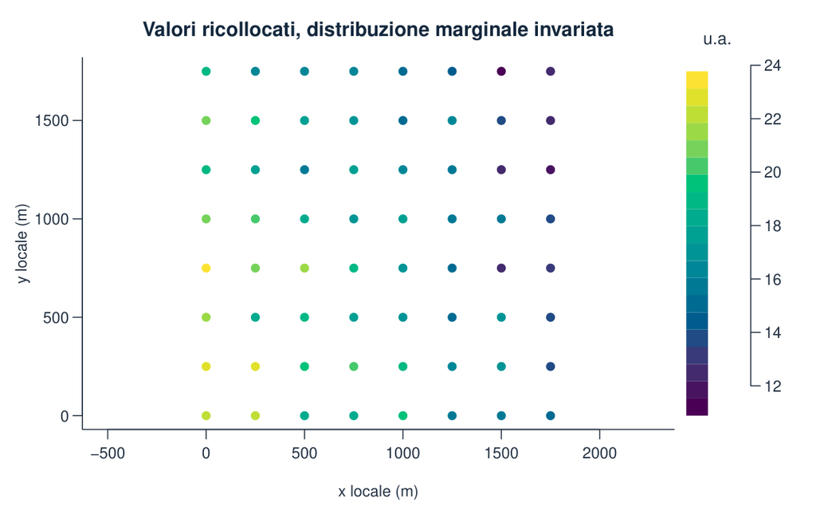

Figura 2 · Output del blocco `variante`. PDF vettoriale.

Questa ricollocazione è deterministica e illustrativa. Non è una procedura inferenziale e non rappresenta nuove misure.

## Errore da riconoscere

Leggere come osservata tutta una superficie colorata o cambiare la scala cromatica fra due carte senza dichiararlo.

## Risposta alla domanda

Una carta di punti collega posizione e misura, lasciando visibili i luoghi non osservati. Distribuzione marginale, configurazione spaziale e superficie prevista sono tre oggetti distinti.

## Raccordo con le slide

Slide 7 e 32–33 della lezione Locus. Il notebook conserva il tema del laboratorio originale e aggiunge verifiche e una variante svolta.

## Riferimenti e provenienza

Questo svolgimento sviluppa `M11_N07` del [modulo M11 del corso](https://marzione00.github.io/Lab_Geo/#modulo-M11). Il [codice originale](https://github.com/marzione00/Lab_Geo/blob/649f7cc577b96bd1044d81e78a2f530813e4f96b/materiali/laboratori/M11/M11_N07.R) è conservato immutato in `R/Originali_corso/`; la mappa allegata documenta gli ampliamenti. Dati e originali hanno impronte SHA-256 e SHA-1 Git verificate.

Documentazione primaria delle operazioni: [R, dist](https://stat.ethz.ch/R-manual/R-devel/library/stats/html/dist.html), [R, aggregate](https://stat.ethz.ch/R-manual/R-devel/library/stats/html/aggregate.html), [R, sample](https://stat.ethz.ch/R-manual/R-devel/library/base/html/sample.html). Le definizioni spaziali e il riferimento inferenziale seguono il laboratorio originale, con le distinzioni esplicitate nel testo.